# 통계밥법론2 Chap5 실습코드

202140191 엄태훈

2021-10-02(SAT)

# Chap5 Mosaic Displays for n-Way Tables

**모자이크 그림**은 변수 간의 연관 패턴을 시각화 하는데 도움이 많이 된다.  
이 기술을 확장하면 부분 연관성, 주변 연관성 등의 구조를 드러낼 수 있다.  
또한, 모자이크 그림은 **Marimekko chart, Eikosogram**이라고도 불리기도 하며, 특히 범주형 데이터에 대해 시각화하는데 아주 유용하다.

## 5.1 Introduction

Chpater4에서 **fourfold display**, **tile plot**, **sieve diagram**, **agreement charts**, **trilinaer plot** 같은 분할표의 연관 패턴을 시각화하기 위한 기술들을 배웠다.

Chapter5에서는 n-way 빈도표를 시각화하기 위한 **mosaic plot**에 대해서 알아본다. 이 방법은 면적이 셀의 빈도에 비례하며, 이런 점에서 **sieve diagram**과 유사하다.  
또한, 3개 이상의 변수를 가지는 고차원 분할표에 대하여 여러 독립성을 가정하여 다양한 모델을 만들어낼 수 있는 **로그 선형 모델**에 대해서도 살펴본다.

**mosaic plot**과 관련된 장점은 아래와 같다.

- n-way 빈도표에 대해서 더 일반화할 수 있다.
- 빈도 데이터에 대한 로그선형 모델, 일반화된 선형 모델 및 일반화된 비선형 모델에 밀접하게 연결한다.
- 순서적인 모델을 n-way 테이블의 다양한 주변 총합에 연결시키기 위한 방법을 제공한다.
- 다양한 로그 선형 모델에 적합된 변수들 사이의 관계를 설명하는데 사용될 수 있다.

R에서는 `vcd`패키지의 `mosaic`함수를 통해 **모자이크 플랏**을 그릴 수 있다.  
- `mosaic(table,suppress,labeling,shade)`

- table: 모자이크 플랏을 그릴 분할표
- suppress: 지정한 값의 절대값을 기준으로 셀에 값을 표시한다.
- labeling: 셀의 라벨링 방법
- shade: 잔차에 대한 음영 처리 여부

## 5.2 Two-way tables

*Example 5.1: Hair color and eye color*

```r
library(vcd)
```

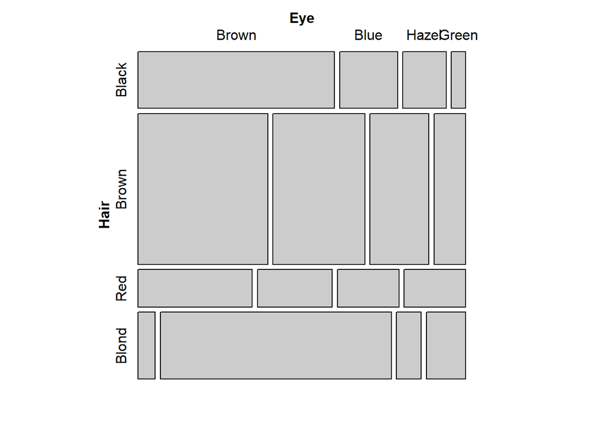

```r
data("HairEyeColor", package = "datasets")
haireye <- margin.table(HairEyeColor, 1:2)
mosaic(haireye)
```

성별 계층을 통일하여 눈의 색깔과 머리 색깔의 분할표를 가지는 `haireye` 데이터를 이용하여 `mosaic plot`을 그려보았다.  
모자이크 플롯의 직사각형 너비는 빈도에 비례하는 것을 볼 수 있으며, **Hair**의 경우, **Hair == Brown**일 경우의 면적이 제일 크므로 갈색 머리를 가진 사람이 가장 많다는 것을 쉽게 알 수 있다.

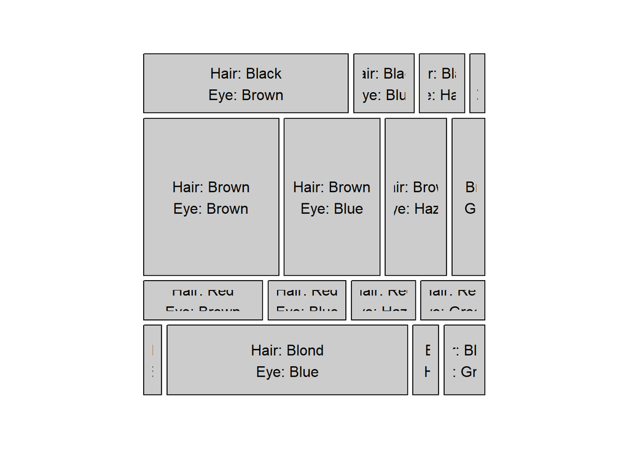

```r
mosaic(haireye,
       labeling = labeling_cells)
```

`labelling = labelling_cells`옵션을 통해 직사각형의 각 셀이 의미하는 변수들의 조합이 무엇인지 살펴볼 수 있다.

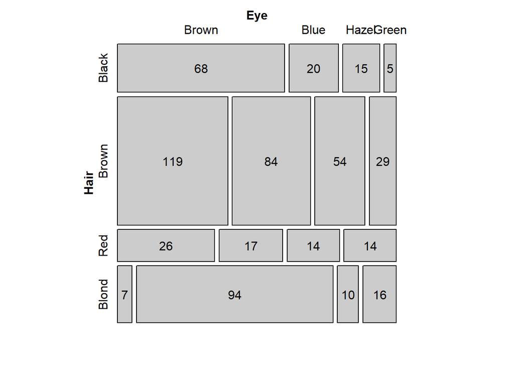

```r
mosaic(haireye,
       labeling = labeling_values)
```

`labeling = labeling_values`옵션을 통해 직사각형위에 빈도를 나타내도록 하였다.  
`haireye` 데이터에서 **Eye = Brown, Hair = Brown**인 사람이 119명으로 가장 많으며, **Eye = Blue, Hair = Blond** 사람이 94명으로 두 번째로 많은 것을 확인할 수 있다.

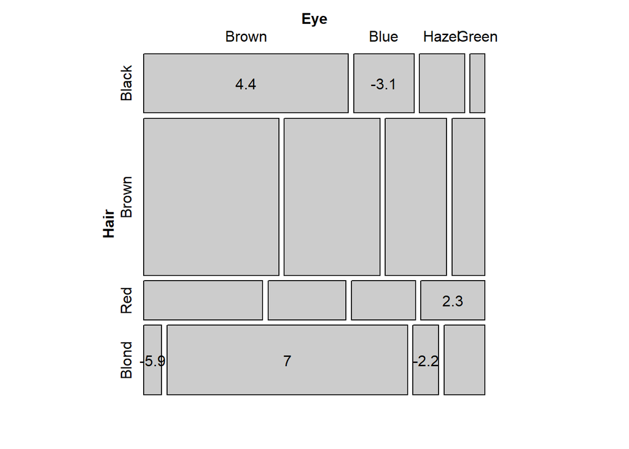

```r
mosaic(haireye,
       labeling = labeling_residuals)
```

`labeling = labeling_residuals`옵션을 지정하게 되면 각 셀이가지고 있는 피어슨 잔차의 값을 출력해준다.  
이 경우, 잔차가 표시되지 않는 셀이 발생하는데 이러한 문제는 `suppress`옵션을 통해 해결할 수 있다.

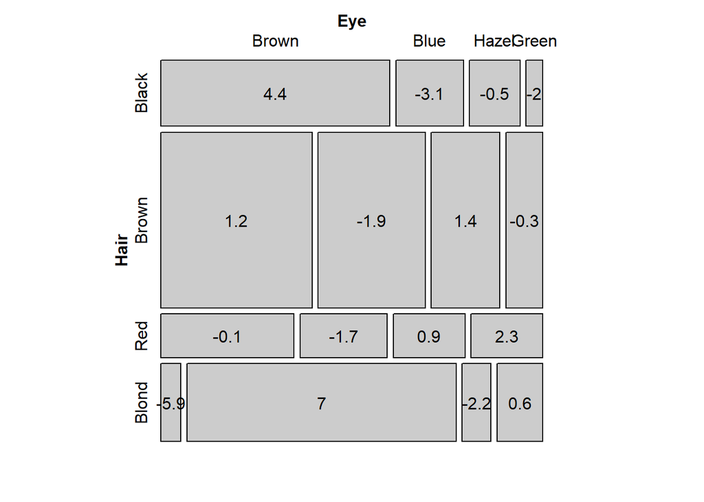

```r
mosaic(haireye,
       suppress = 0,
       labeling = labeling_residuals)
```

`suppress`옵션은 위의 `mosaic`함수 설명에서도 살펴볼 수 있듯이, 분석가가 지정한 절댓값을 기준으로 잔차를 출력해준다.  
`suppress = 0`을 지정하게 되면 절대값 0을 기준으로 잔차를 출력해달라는 의미로 모든 잔차가 출력되는 것을 확인할 수 있다.

```r
(hair <- margin.table(haireye,1))
```

```
## Hair
## Black Brown   Red Blond
##   108   286    71   127
```

`margin.talbe`함수를 이용하여 Eye의 색깔에 상관없이 Hair 색깔의 빈도를 구해 보았다.  
Hair 색깔이 **Brown, Blond, Black, Red**의 순서로 많은 것을 확인할 수 있다.

```r
expected <- rep(sum(hair) / 4,4)
names(expected) <- names(hair)
expected
```

```
## Black Brown   Red Blond
##   148   148   148   148
```

marginal표의 기대 빈도는 모든 요소들의 빈도를 더한 후 범주의 갯수로 나누기 때문에 동일한 기댓값을 갖게 된다. 여기서는 hair 색깔들의 기대 빈도가 148로 모두 동일한 것을 확인할 수 있다.

```r
(residuals <- (hair - expected) / sqrt(expected))
```

```
## Hair
##     Black     Brown       Red     Blond
## -3.287980 11.343530 -6.329361 -1.726189
```

피어슨 잔차공식($r_i = (n_i-m_i)/ \sqrt{(m_i)}$)을 이용하여 잔차를 구한 결과는 위와 같다.

Brown을 제외한 나머지 3개의 컬러는 음의 값을 갖는 것을 알 수 있다.  
잔차가 음의 값을 갖는다는 것은 기대빈도가 관찰빈도보다 높다는 의미이고 잔차가 양의 값을 갖는다는 것은 관찰빈도가 기대빈도보다 높다는 의미이다.

즉, **Hair = Brown**인 경우에는 관찰빈도가 기대빈도보다 높고 나머지 나머지 3개의 컬러의 경우, 기대빈도가 관찰빈도보다 높다는 것을 알 수 있다.

```r
round(addmargins(prop.table(haireye,1),2),3)
```

```
##        Eye
## Hair    Brown  Blue Hazel Green   Sum
##   Black 0.630 0.185 0.139 0.046 1.000
##   Brown 0.416 0.294 0.189 0.101 1.000
##   Red   0.366 0.239 0.197 0.197 1.000
##   Blond 0.055 0.740 0.079 0.126 1.000
```

`addmargins`함수와 `prop.table`함수를 이용하여 Hair의 색깔에 따른 Eye의 확률표를 구해보았다.  
**Hair = Black** 일 때, **Eye = brown**,  
**Hair = Brown** 일 때, **Eye = brown**,  
**Hair = Red**일 때, **Eye = Brown**,  
**Hair = Blond**일 때, **Eye = Blue**의 비율이 각각의 **Hair**에서 가장 높은 것을 확인할 수 있다.

```r
exp <- independence_table(haireye)
resids <- (haireye - exp) / sqrt(exp)
round(resids, 2)
```

```
##        Eye
## Hair    Brown  Blue Hazel Green
##   Black  4.40 -3.07 -0.48 -1.95
##   Brown  1.23 -1.95  1.35 -0.35
##   Red   -0.07 -1.73  0.85  2.28
##   Blond -5.85  7.05 -2.23  0.61
```

marginal 표가 아닌 2-way표의 경우 기대빈도를 계산할 때, 조금 다른 식을 이용해서 계산해야 한다.($m_{ij} = n_{++} * \pi_{i+} * \pi_{+j}$)

앞선 Chapter에서 살펴본 것처럼 분할표의 기대빈도는 `independence_table`함수를 이용하여 쉽게 계산할 수 있다.  
위의 결과는 `independence_table`함수를 통해 기대빈도를 구하고 관찰빈도를 이용하여 잔차를 구한 값이다.

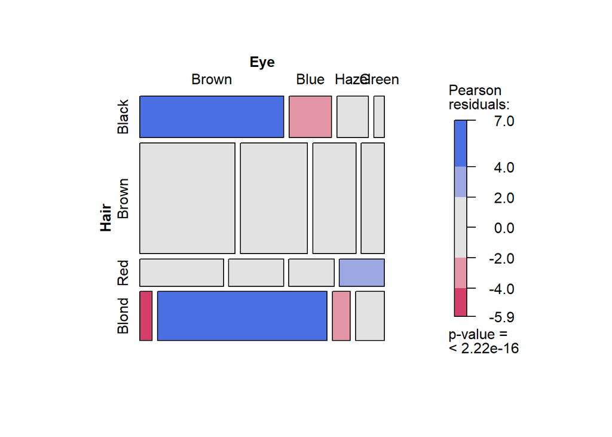

```r
mosaic(haireye,shade=TRUE)
```

모자이크 플랏을 통해 잔차진단을 진행할수도 있다. `mosaic`함수에서 `shade = True`를 주게되면 피어슨 잔차에 값의 따라 직사각형의 셀의 색깔을 바꿔준다.  
파란색의 경우 양의 잔차를 가지며, 해당셀의 관찰빈도가 기대빈도보다 높고, 빨간색의 경우 음의 잔차를 가지며, 해당셀의 관찰빈도가 기대빈도보다 낮다는 의미이다.

여기서는, **Eye = Brown, Hair = Black**, **Eye = Green, Hair = Red**, **Eye = Blue, Hair = Blond**가 관찰빈도가 기대빈도보다 높아 파란색으로 표시된다.

**Eye = Blue, Hair = Black**, **Eye = Brown, Hair = Blond**, **Eye = Hazel, Hair = Blond**의 경우 관찰빈도가 기대빈도보다 낮으므로 빨간색으로 표시되는 것을 확인할 수 있다.

우측 하단 아래에 있는 P-value는 피어슨 카이제곱 검정통계량을 통해 독립성 검정을 진행한 결과이다.

귀무가설$H_0$: 주어진 두 변수는 독립이며, 연관성이 없다.  
대립가설$H_1$: 주어진 두 변수는 독립이 아니며, 연관성이 있다.

유의확률이 유의수준 0.05보다 작으므로 귀무가설을 기각한다. 따라서, **Hair Color**, **Eye Color**는 서로 독립이 아니며 연관성이 있다고 볼 수 있다.

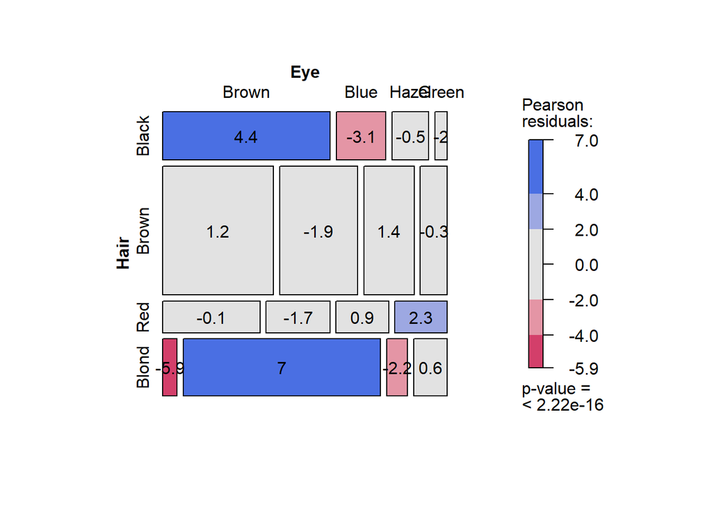

```r
mosaic(haireye,shade=TRUE,
       suppress = 0,
       labeling = labeling_residuals)
```

`suppress`와 `labeling`옵션을 활용하여 잔차에 따른 음영 처리와 더불어 잔차값을 출력할 수 있다.

```r
(chisq <- sum(resids ^2))
```

```
## [1] 138.2898
```

```r
(df <- prod(dim(haireye) - 1))
```

```
## [1] 9
```

```r
pchisq(chisq, df, lower.tail = FALSE)
```

```
## [1] 2.325287e-25
```

피어슨 잔차값을 이용하여 피어슨 검정통계량을 구한 후, 검정통계량 값을 통해 가설검정을 진행해 보았다.  
모자이크 플랏에서 살펴본 결과와 동일하게 유의확률이 유의수준 0.05보다 작아 **Hair Color**, **Eye Color**는 서로 독립이 아닌 것을 확인할 수 있다.

```r
chisq.test(haireye)
```

```
##
##  Pearson's Chi-squared test
##
## data:  haireye
## X-squared = 138.29, df = 9, p-value < 2.2e-16
```

`chisq.test`함수를 사용하여 독립성 검정을 진행한 결과, 동일한 결과를 얻을 수 있는 것 또한 확인할 수 있다.

### 5.2.2 Interpretation and reordering

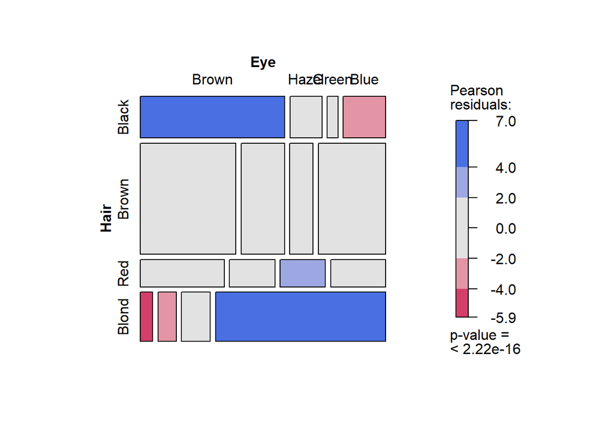

```r
haireye2 <- as.table(haireye[, c("Brown","Hazel","Green","Blue")])
mosaic(haireye2, shade = TRUE)
```

해석의 용이함을위해 주어진 데이터의 범주를 재구성한 후, **모자이크 플롯**을 그릴 수 있다.  
`haireye`데이터에서 눈 색깔의 범주 순서를 어두운색에서 밝은 색으로 정렬한 후 다시 한 번 **모자이크 플롯**을 그려보았다.

상대적으로 어두운 눈색깔인 **Brown, Hazel**을 가질 때, **Blond**머리를 가지는 사람은 적은 것을 알 수 있다.  
이처럼 범주의 수준에 대해서 순서를 재구성하게 되면 상대적으로 해석과 변수들의 패턴을 찾는데있어 편리한 것을 확인할 수 있다.

## 5.3 The strucplot framework

모자이크 그림은 앞서 4장에서 살펴본 **sieve plot, association plot**, 후에 뒤에서 살펴볼 **doubledecker plot**과 많은 공통점이 있다.  
이 방법들의 주요한 공통점은 분할표의 빈도를 tile로써 시각화 한다는데에 있다.

데이터를 단순히 시각화 하는 것도 중요하지만, 시각화된 결과를 보고함에 있어 적절한 색조화 혹은 간격배치를 통해 결과를 쉽게 살펴볼 수 있게 하는 것 또한 중요한 요소이다.  
**strucplot framework**는 이렇게 시각화를 세밀하게 조절하는데 사용될 수 있는 다양한 함수를 제공한다. 이 프레임워크는 그래픽의 측면을 세심하게 컨트롤 할 수 있는 conditional 그림의 클래스를 제공한다.

`strucplot`은 이처럼 고차원 분할표의 특정 측면을 계층적 방식으로 시각화하며, 기존에 가지는 분할표 시각화 기법과 더불어 더 다양한 조절 옵션을 가지고 있다.  
`strucplot`은 `vcd`패키지 안에 포함돼있다.  
- `strucplot(table, core, gp, spacing)`

- table: strucplot을 적용할 분할표
- core: 표현하고자하는 시각화 형태(default는 모자이크 플랏)
- spacing: 간격 조정
- gp: 색깔 조정 및 그래프의 시각적 요소 조정

Ex)

- 타일의 라벨링
- 타일 사이의 간격
- 타일의 시각적 요소
- 타일의 내용

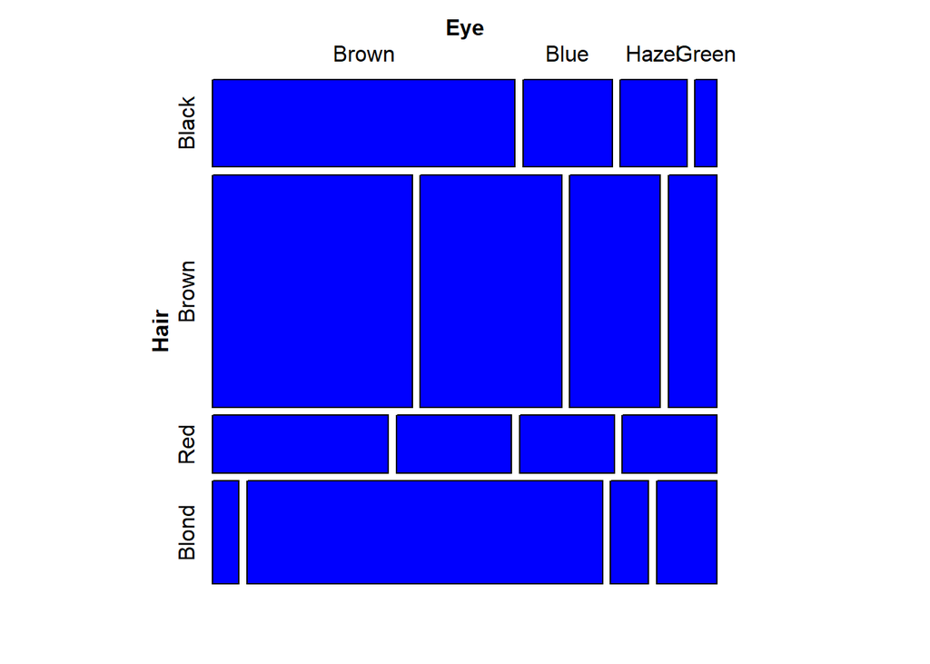

```r
strucplot(haireye, gp = gpar(fill = "blue"))
```

`strucplot`함수를 이용하여 `haireye`의 모자이크 플롯을 그린 후, `gp`옵션을 통해 타일의 색깔을 바꿔주었다.

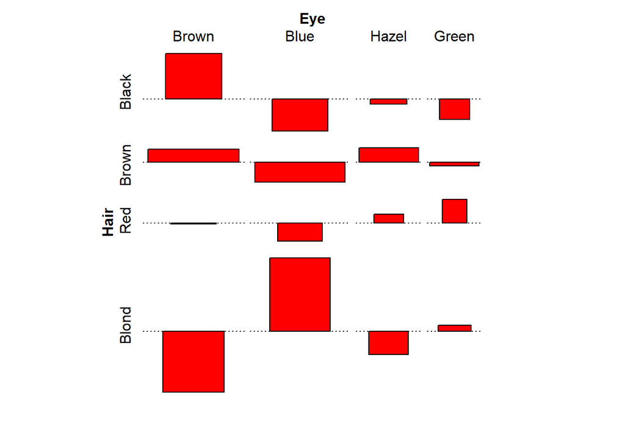

```r
strucplot(haireye,core = struc_assoc,spacing = spacing_increase, gp = gpar(fill ="red"))
```

`core`함수를 통해 시각화의 형태를 `association plot`으로 지정한 후, `gp`옵션을 통해 타일의 색깔을 빨간색으로 바꿔주었다.

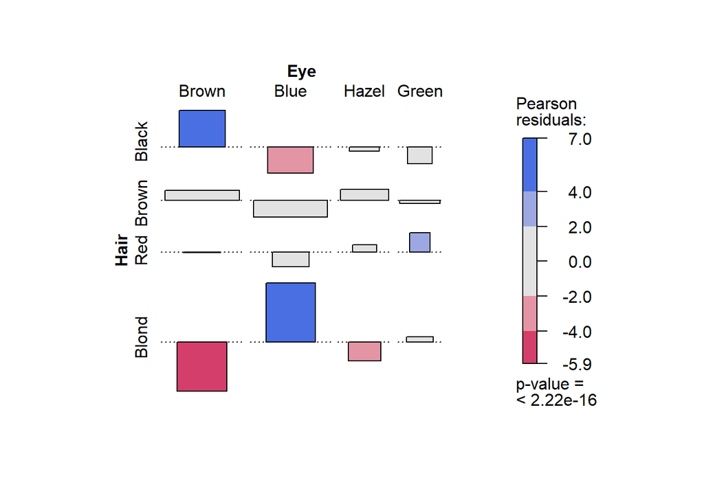

```r
strucplot(haireye,core = struc_assoc,shade = TRUE)
```

`strucplot`또한 잔차에 따른 음영처리 여부인 `shade`옵션을 제공한다.

### 5.3.2 Shading schemes

#### 5.3.2.1 Specifying graphical parameters for strucplot displays

```r
fill_colors <- c("brown4","#acba72","green","lightblue")
(fill_colors_mat <- t(matrix(rep(fill_colors,4),ncol=4)))
```

```
##      [,1]     [,2]      [,3]    [,4]
## [1,] "brown4" "#acba72" "green" "lightblue"
## [2,] "brown4" "#acba72" "green" "lightblue"
## [3,] "brown4" "#acba72" "green" "lightblue"
## [4,] "brown4" "#acba72" "green" "lightblue"
```

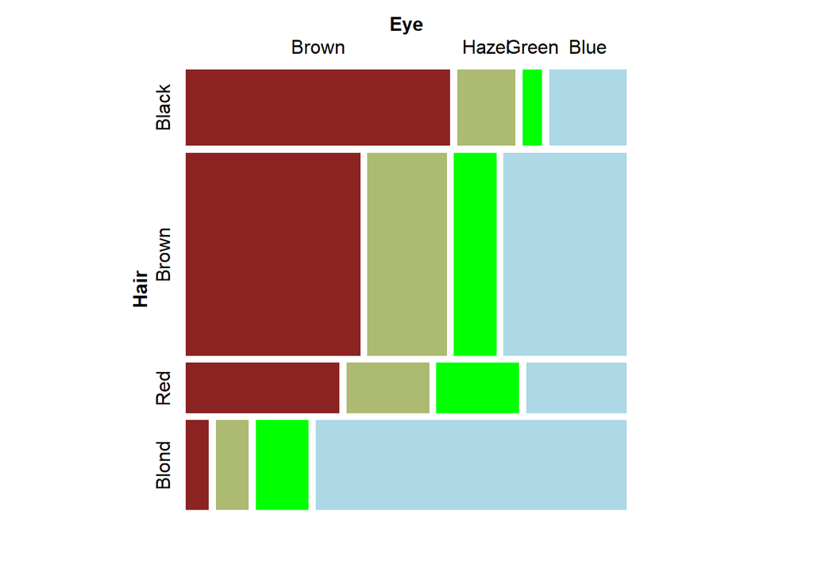

```r
mosaic(haireye2, gp = gpar(fill = fill_colors_mat, col = 0))
```

기본적인 color가 아닌 특정 color를 정의하여 모자이크 플롯을 구성할 수 있다. 위의 코드에서는 원하는 color를 정의한 후, `gp = gpar(fill)` 옵션을 통해 정의한 color를 넣어주었다.

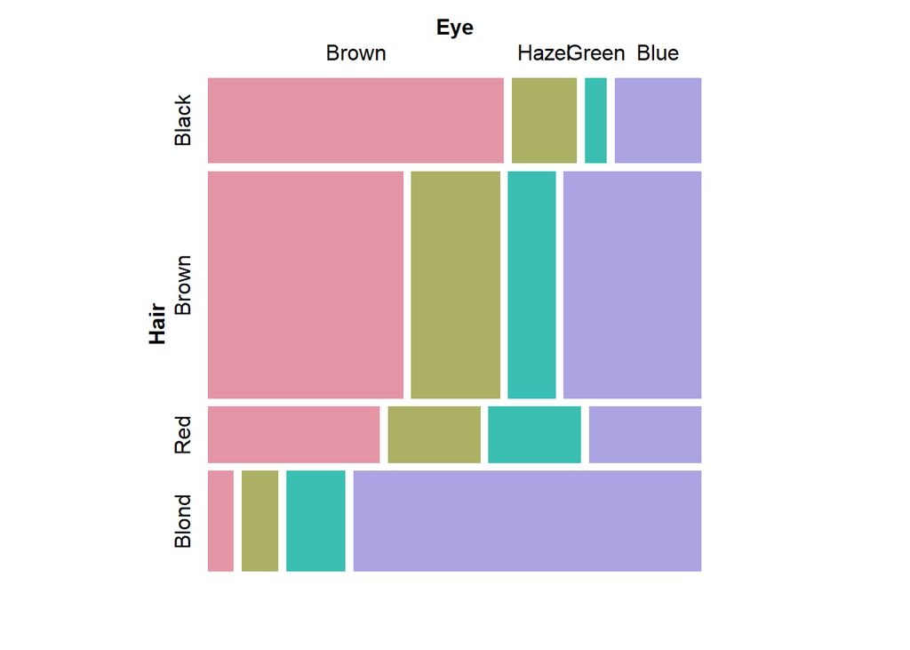

```r
mosaic(haireye2, gp = shading_Marimekko(haireye2))
```

`gp=shading_Marimekko(객체)`를 통해 미리 정의돼있는 색깔을 불러올 수 있다.

```r
library(colorspace)
toeplitz(1 : 4)
```

```
##      [,1] [,2] [,3] [,4]
## [1,]    1    2    3    4
## [2,]    2    1    2    3
## [3,]    3    2    1    2
## [4,]    4    3    2    1
```

`colorspace`패키지는 다양한 컬러를 매핑할 수 있도록 수많은 파레트 옵션을 가지고 있는 패키지이다.

`toeplitz`함수는 대칭행렬을 만들어주는 함수이다.  
- `toeplitz(x)`

- x: 대칭행렬을 만들 숫자들

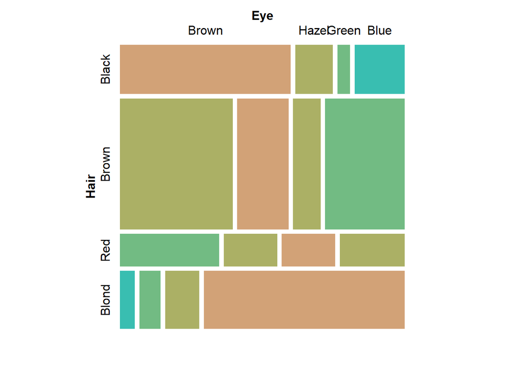

```r
fill_colors <- rainbow_hcl(8)[ 1 + toeplitz(1 : 4)]
mosaic(haireye2, gp = gpar(fill = fill_colors, col = 0))
```

`rainbow_hcl`함수는 HCL 색상 팔레트를 제공하는 함수로 `colorspace`패키지에 포함돼 있다.  
- `rainbow_hcl(n)`

- n: 생성하고자 하는 파레트의 수

시각화를 진행함에 있어 특정 위치를 색깔을 통해 강조하고 싶은 경우가 있을 수 있다.  
위의 그림의 경우 `toeplitz`함수를 이용하여 대각선상에 있는 셀의 색깔을 동일하게 해주며, 나머지 셀 또한 대칭에 따라 동일한 색을 가지는 것을 볼 수 있다.

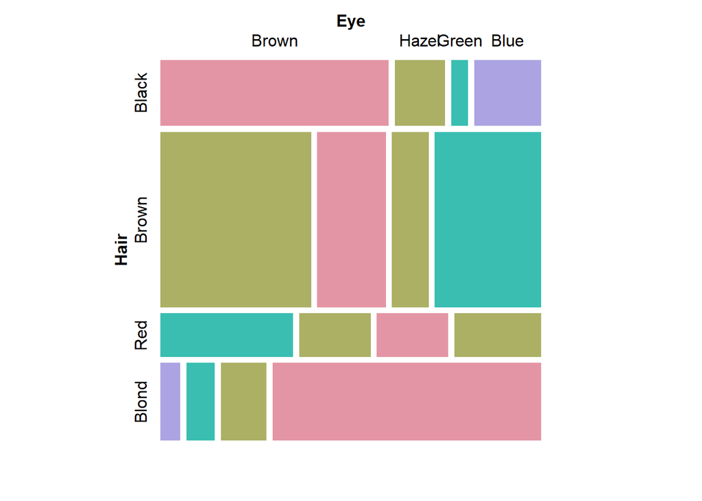

```r
mosaic(haireye2, gp = shading_diagonal(haireye2))
```

`gp = shading_diagonal(객체명)`을 통해 대각상의 셀에 대해 동일한 색깔을 할수도 있다.

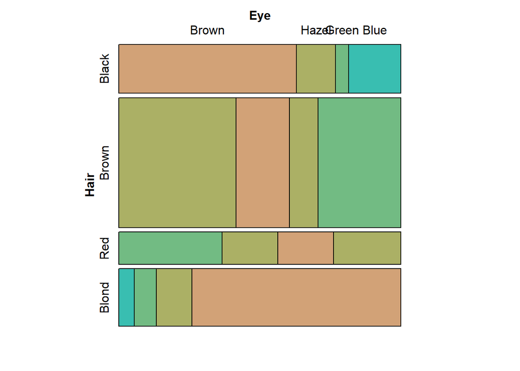

```r
mosaic(haireye2, highlighting = "Eye",
       highlighting_fill = fill_colors)
```

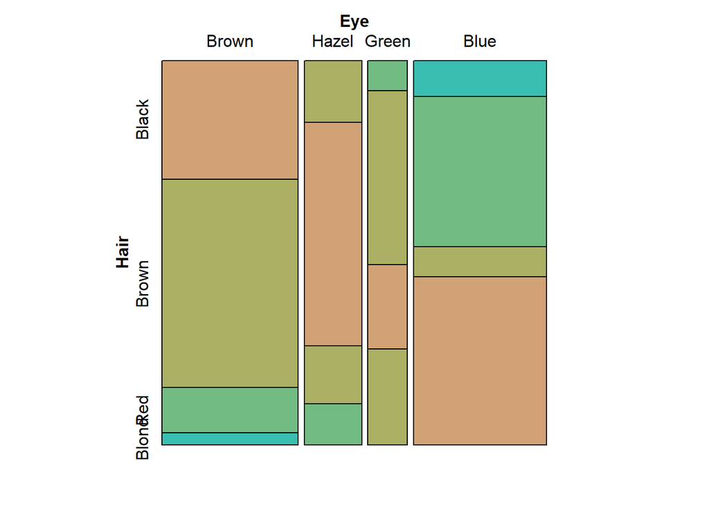

```r
mosaic(haireye2, highlighting = "Hair",
       highlighting_fill = fill_colors)
```

한 변수의 수준에 따라 모자이크를 음영처리 할수도 있다.  
R에서는 `mosaic`함수에서 `highlighting`, `highlighting_fill` 옵션을 통해 쉽게 진행할 수 있다. 위의 그림은 `highlighting`옵션을 `Eye`로 지정했기 때문에, `Eye`의 수준을 쉽게 살펴보고자 `Hair`변수의 수준마다 간격이 띄어져 있는것을 확인할 수 있다.  
아래의 그림은 `highliting`옵션을 `Hair`로 지정했기때문에, `Hair`의 수준을 쉽게 살펴보고자 `Eye`변수의 수준마다 간격이 띄어져 있는것을 확인할 수 있다.

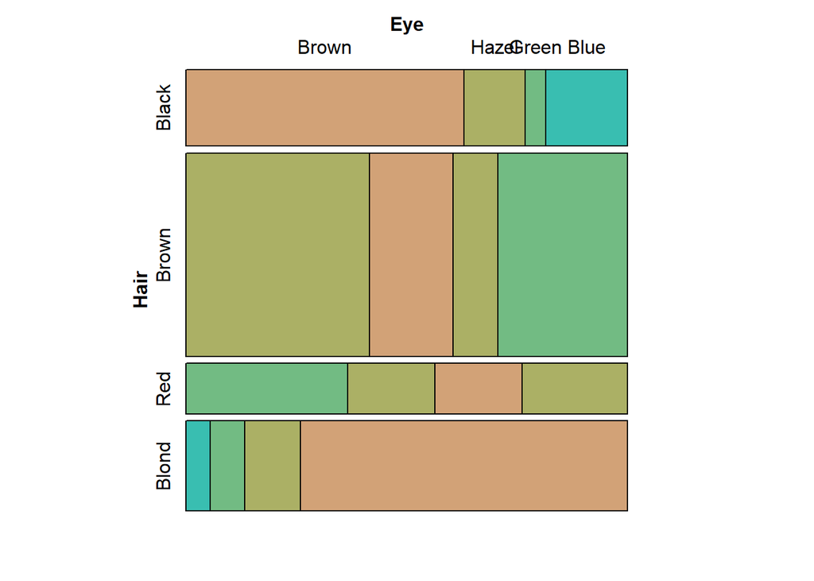

```r
mosaic(Eye ~ Hair, data = haireye2, highlighting_fill = fill_colors)
```

`highlighting`옵션을 이용하기 번거롭다면, formula의 형태 (단, 반응변수 ~ 독립변수)로 구성한 후, `highlighting_fill`옵션만 이용하여 진행할수도 있다.

#### 5.3.2.2 Residual-based shading

*Example 5.2: Interpolation options*

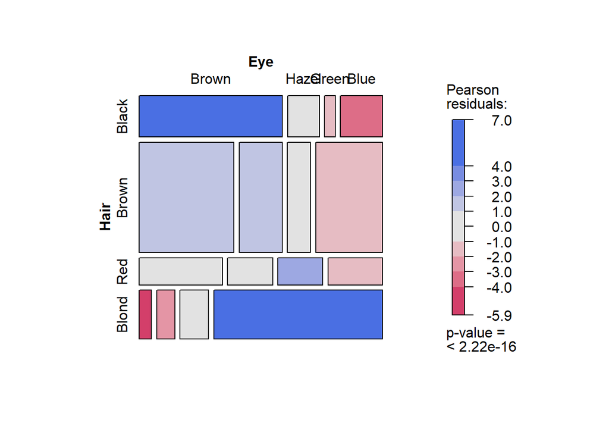

```r
mosaic(haireye2, shade = TRUE, gp_args = list(interpolate = 1:4))
```

모자이크 플롯에서 잔차를 표시함에 있어 색의 농도를 고려하는 것도 중요하다.  
`gp_args = list(interpolate)`옵션은 지정한 범위만큼의 잔차를 나눈 후, 나눠진 값에 따라 음영을 조절해준다.  
위의 코드에서는 `interpolate = 1:4`로 지정하였기 때문에 양의 잔차와 음의 잔차의 최대값을 제외하고 절댓값 (1,4)의 범위로 음영을 나눠준 것을 확인할 수 있다.

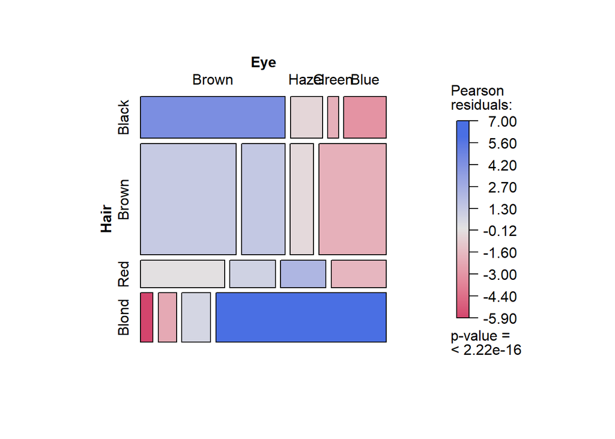

```r
interp <- function(x) pmin(x / 6, 1)
mosaic(haireye2, shade = TRUE, gp_args = list(interpolate = interp))
```

데이터에 맞는 함수를 만든 후, 분석가가 원하는 간격만큼으로 설정하여 잔차의 음영을 조절할수도 있다.

*Example 5.3: Shading functions*

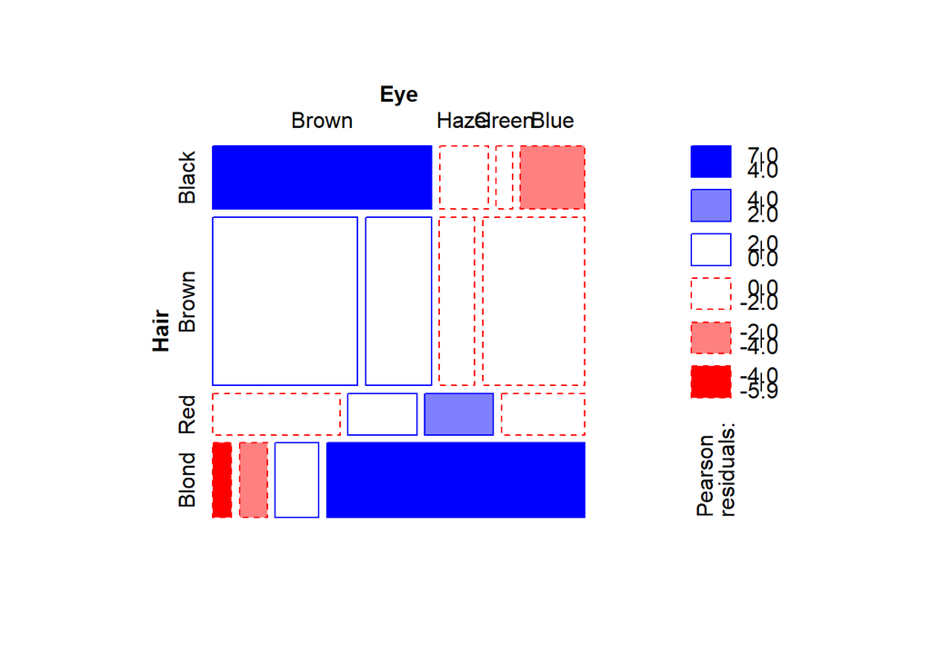

```r
mosaic(haireye2, gp = shading_Friendly, legend = legend_fixed)
```

색의 농도 뿐만 아니라 잔차의 범위에 따라 직사각형의 형태를 바꿔주는 것도 가능하다.  
위의 예시에서는 `gp = shading_Friendly` 옵션을 통해 기존의 빨간색, 파란색으로 양의 잔차, 음의 잔차를 구분하고 잔차의 범위에 따라 직사각형의 선을 점선, 실선의 형태로 바꿔주었다.

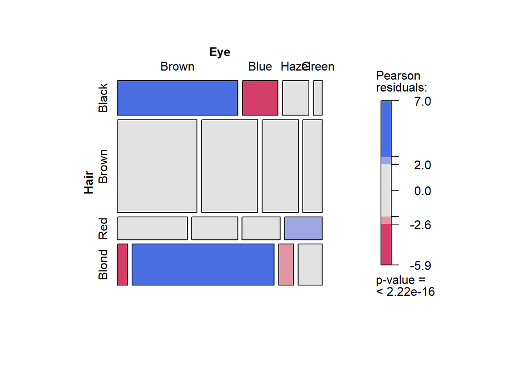

```r
set.seed(1234)
mosaic(haireye, gp = shading_max)
```

`gp = shading_max`옵션을 사용하게 되면, 순열기반 검정을 바탕으로 잔차의 유의성을 확인한 후, 유의한 차이가 있다고 판단되는 잔차를 모자이크 플롯에 표시해주게 된다.

*Example 5.4: Arthritis treatment*

```r
art <- xtabs(~ Treatment + Improved, data = Arthritis, subset = Sex == "Female")
names(dimnames(art))[2] <- "Improvement"
```

`Arthritis`데이터를 처방된 약과 약의 효과에 대한 빈도를 가지는 분할표 형태로 만들어주었다.

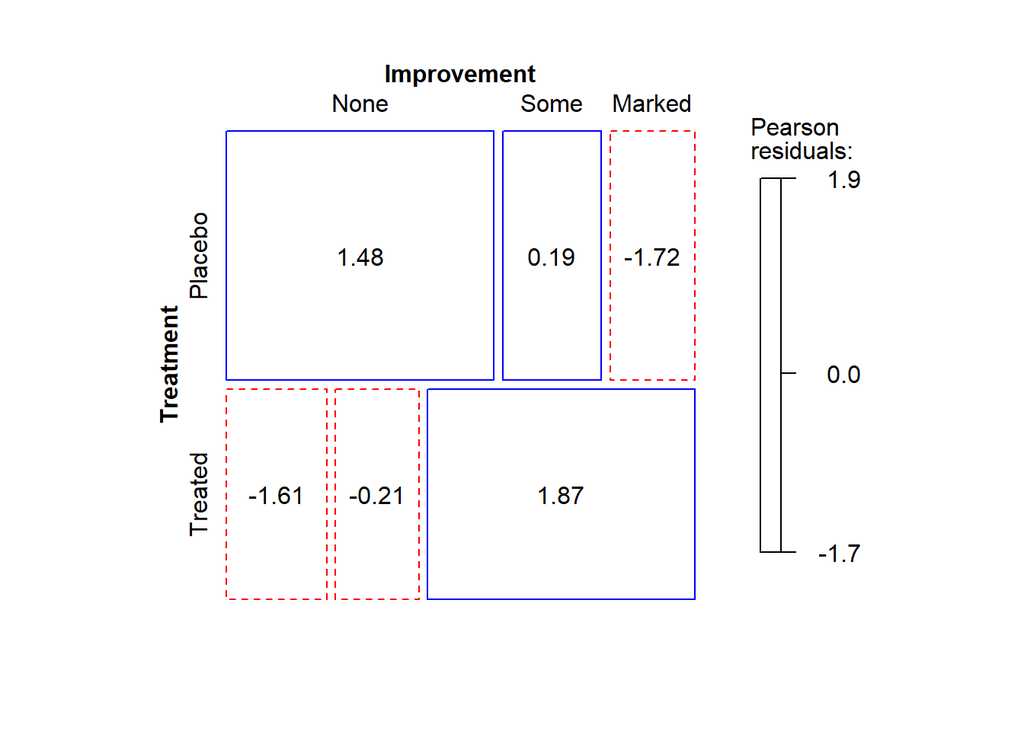

```r
mosaic(art, gp = shading_Friendly, margin = c(right = 1), labeling = labeling_residuals, suppress = 0, digits = 2)
```

`Arthritis*` 데이터의 모자이크 플롯을 그려보았다.

`gp = shading_Friendly`를 통해 잔차의 값에 따라 직사각형의 형태를 바꿔주고 `labeling = labeling_residuals`를 통해 잔차의 값을 직사각형 안에 표시해 주었다. `digits`옵션은 지정된 소수점까지 표시하여 출력해달라는 옵션이다.

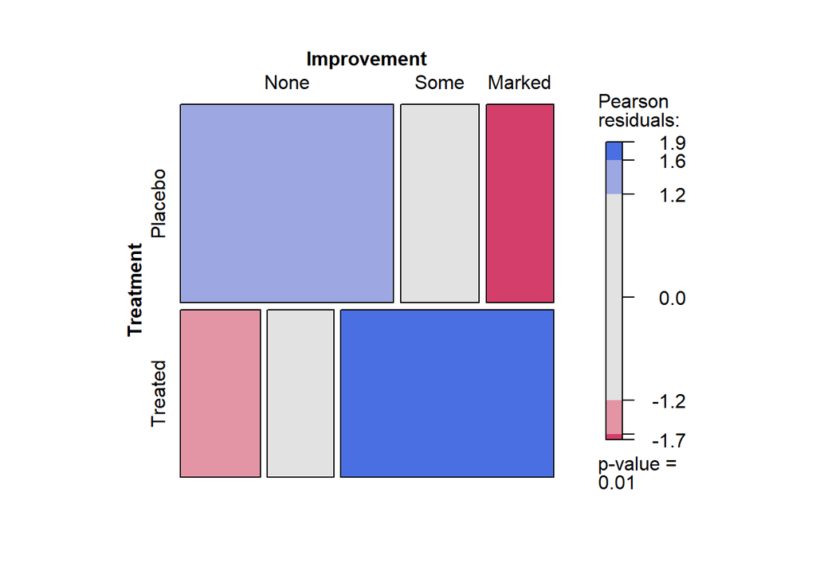

```r
set.seed(1234)
mosaic(art, gp = shading_max, margin = c(right = 1))
```

`shading_max`옵션을 통해 유의한 잔차만을 나타내게 하였다.  
그 결과, **Improvement = None, Treatment = Placebo**, **Improvement = Marked, Treatment = Treated**의 경우 파랑색으로 관찰빈도가 기대빈도보다 높은 것을 알 수 있다.  
반대로, **Improvement = Marked, Treatment = Placebo**, *Improvement = None, Treatment = Treated**의 경우 빨간색으로 관찰빈도가 기대빈도보다 낮은 것을 알 수 있다.  
따라서, 약이 실제 약인 경우, 효과가 나타나지 않는 것 보다 효과가 뚜렷한 경우가 많았고 약이 위약일 경우 효과가 뚜렷한 것보다 나타나지 않는 경우가 더 많았다.

```r
residuals(chisq.test(art))
```

```
##          Improvement
## Treatment       None       Some     Marked
##   Placebo  1.4775223  0.1926666 -1.7173377
##   Treated -1.6085225 -0.2097488  1.8696005
```

`residuals`함수를 통해 `chisq.test`의 결과에서 잔차값만 출력할 수 있다.  
잔차값을 살펴보면, 앞에서 모자이크 플롯을 통해 살펴본 결과와 동일한 것을 확인할 수 있다.

```r
set.seed(1234)
art_max <- coindep_test(art)
art_max
```

```
##
##  Permutation test for conditional independence
##
## data:  art
## f(x) = 1.8696, p-value = 0.01
```

`shading_max`를 사용할 때, p-value는 `coindep_test`를 통해 검정이 되고 `coindep_test`의 결과에 따라 유의성이 검정된다.  
`coindep_test`는 동일한 여백을 가진 n개의 랜덤 테이블을 생성하여 각각에 대한 최대 잔차 통계량을 계산한 후, conditional 독립성에 따른 분할표의 conditional 독립성 검정을 수행한다. 이때 얻어지는 P-value를 범례에 표시한다.  
`coindep_test`는 `vcd`패키지에 포함돼있다.  
- `coindep_test(table)`

- table: conditional independence test를 시행할 분할표

`coindep_test`결과 유의확률은 유의수준 0.05보다 작으므로 귀무가설을 기각한다. 따라서, **Treatment, Improvement**두 변수는 서로 독립이 아니며 연관성이 있다고 해석할 수 있다.

```r
art_max$qdist(c(0.90, 0.99))
```

```
##      90%      99%
## 1.239278 1.646330
```

마지막으로, 시뮬레이션 분포의 90% ~ 99% quantile을 음영의 수준으로 사용하게 된다.  
즉, `Arthritis`데이터의 음영의 수준은 앞선 그림에서 출력된대로 (1.2,1.6)의 범위를 사용한다.

*Example 5.5: UK soccer scores*

```r
library(vcdExtra)
data("UKSoccer", package = "vcd")
CMHtest(UKSoccer)
```

```
## Cochran-Mantel-Haenszel Statistics for Home by Away
##
##                  AltHypothesis   Chisq Df    Prob
## cor        Nonzero correlation  1.0105  1 0.31479
## rmeans  Row mean scores differ  5.6263  4 0.22885
## cmeans  Col mean scores differ  7.4161  4 0.11547
## general    General association 18.6501 16 0.28723
```

`CMHtest`를 통해 `UKSoccer`데이터에 대한 독립성 검정을 진행해 보았다.  
4가지의 방법을 모두 적용했을 때의 유의확률이 유의수준 0.05보다 크므로 귀무가설을 기각하지 못한다.  
즉, 홈경기의 득점과 원정경기의 득점은 서로 독립인 것을 알 수 있다.

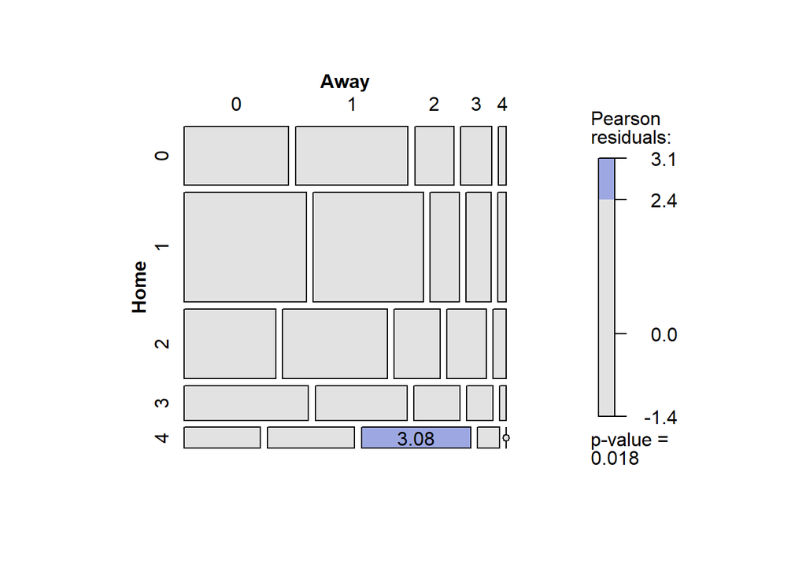

```r
set.seed(1234)
mosaic(UKSoccer, gp = shading_max, labeling = labeling_residuals, digits = 2)
```

`shading_max`를 사용한 모자이크 플롯의 결과, **Away = 2, Home = 4**인 경우 관찰빈도가 기대빈도보다 높게 나온것을 확인할 수 있고 유일하게 유의한 잔차인 것을 알 수 있다.  
`coindep_test`의 결과는 유의확률이 유의수준 0.05보다 작으므로 귀무가설을 기각한다. 즉, 원정경기 득점과 홈경기 득점은 서로 연관이 있다라고 할 수 있다.  
하지만, 모자이크 플롯을 살펴보면 원정경기의 득점과 홈경기 득점간에는 큰 연관이 있는 것처럼 보이지 않는다.

## 5.4 Three-way and larger tables

*Example 5.6: Hair color, eye color, and sex*

```r
HEC <- HairEyeColor[, c("Brown","Hazel","Green","Blue"),]
```

`HairEyeColor`에서 앞서 진행한 전처리 과정과 달리 계층변수인 성별 변수를 제외하지 않고 변수의 수준을 재지정한 후, `HEC`객체에 저장하였다.

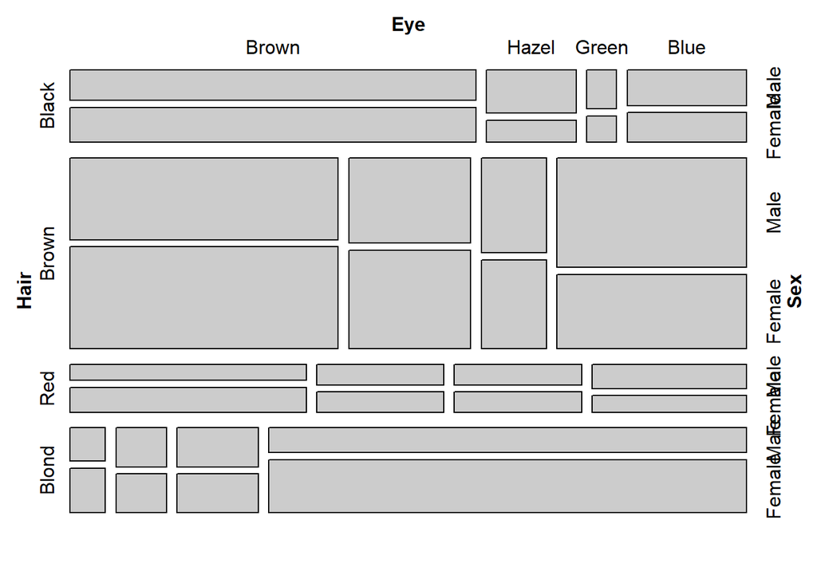

```r
mosaic(HEC)
```

성별을 계층변수로하는 3차원의 모자이크 플롯을 그려보았다.  
2차원과 달리 3차원부터는 셀에 출력되는 정보가 없으면 모자이크 플롯을 해석하기가 약간은 난해한 것을 확인할 수 있다.

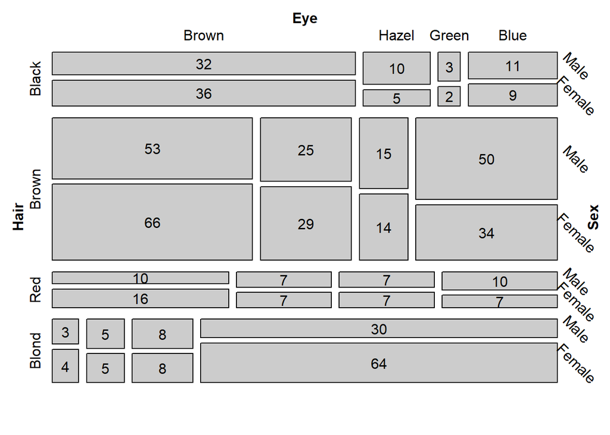

```r
mosaic(HEC,
       rot_labels = c(right = -45),
       labeling = labeling_values)
```

`labeling`옵션을 통해 직사각형의 각 셀에 빈도를 표시하도록 하였다.  
여성과 남성 모두 **Hair = Brown, Eye = Brown**인 사람이 가장 많은 것을 확인할 수 있다.

3-way 이상의 모자이크 플롯을 그리는 경우 변수들의 이름이 잘 보이지않는 경우가 발생할 수 있다.  
이때, `rot_labels`함수를 통해 이름의 위치를 약간 조정해주게 되면, 시각적으로 더 나은 결과를 제공할 수 있게 만들어줄 수 있다.

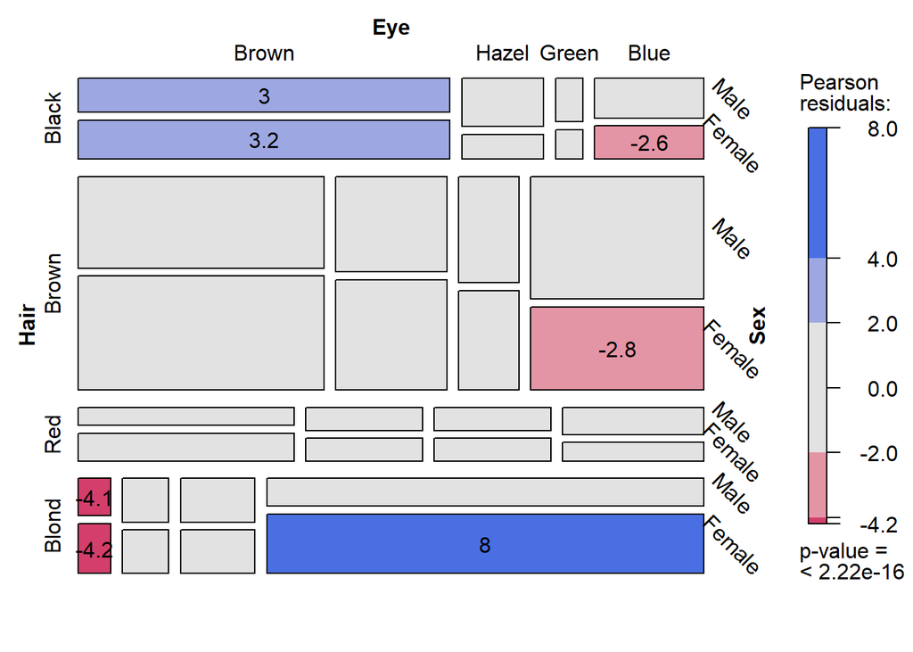

```r
mosaic(HEC,
       rot_labels = c(right = -45),
       labeling = labeling_residuals,
       shade = TRUE)
```

`shade`옵션을 통해 잔차의 값에 따라 음영을 다르게 하도록 하였다.  
남성과 여성 모두 **Hair = Black, Eye = Brown**일때, 양의 잔차를 가지므로 관찰빈도가 기대빈도보다 큰 것을 알 수 있고 **Hair = Blond, Eye = Brown**일때, 음의 잔차를 가지므로 관찰빈도가 기대빈도보다 낮은 것을 확인할 수 있다.

또한, 유의확률이 유의수준 0.05보다 작으므로 성별을 계층으로 하는 머리색과 눈색깔에 대한 분할표는 유의하다.  
즉, 성별을 계층으로 했을 때 머리색과 눈색깔은 서로 연관이 있는 것을 알 수 있다.

### 5.4.1 A primer on loglinear models

로그선형 모델의 기본 개념은 **독립성(sieve diagram, mosaic plot)하에서 기대빈도 간의 곱셈관계가 로그 빈도에 대한 모댈로서 표현**이 될 때 가법모델이 된다는 것이다.  
즉 우리가 알고있는 두 이산 변수의 기대빈도의 경우, 한 값이라도 0이되면 기대빈도가 0이되는 문제가 발생한다. 하지만, 여기에 로그를 취하게 되면 기대빈도가 0이 되는 문제를 방지할 수 있으므로, **로그선형모델**은 상당히 유의하게 사용할 수 있다.

*Example 5.7: Hair color, eye color, and sex*

`loglin`함수는 반복적인 비례 적합을 통해 다차원 분할표에 로그 선형 모델을 적합시키는 데 사용된다.  
- `loglin(table,margin)`

- table: `loglin`함수를 적용할 분할표 데이터
- margin: 모형을 적합시킴에 있어 사용할 행 또는 열

`loglm`함수는 로그 선형 모델을 glm과 같은 다른 피팅 함수의 모델과 유사한 방식으로 지정할 수 있도록한다.  
`loglm`함수는 `MASS`패키지 안에 포함돼 있다.  
- `loglm(formula,data)`

- formula: 사용자가 적합하고자 하는 모델의 구성식
- data: 변수에 사용된 데이터

```r
set.seed(12345)
n <- 100
A <- factor(sample(c("a1","a2"),n, replace = TRUE))
B <- factor(sample(c("b1","b2"),n, replace = TRUE))
sex <- factor(sample(c("M","F"),n, replace = TRUE))
age <- round(rnorm(n, mean = 30, sd = 5))
mydata <- data.frame(A, B, sex, age)
mytable <- xtabs(~ A + B + sex, data = mydata)
```

```r
loglin(mytable, margin = list(1,2))
```

```
## 2 iterations: deviation 0
```

```
## $lrt
## [1] 6.891656
##
## $pearson
## [1] 6.368757
##
## $df
## [1] 5
##
## $margin
## $margin[[1]]
## [1] "A"
##
## $margin[[2]]
## [1] "B"
```

```r
loglin(mytable, margin = list(c(1,2)))
```

```
## 2 iterations: deviation 0
```

```
## $lrt
## [1] 5.041023
##
## $pearson
## [1] 4.959567
##
## $df
## [1] 4
##
## $margin
## $margin[[1]]
## [1] "A" "B"
```

`mytable`데이터를 `loglin`함수를 이용하여 로그 선형모델에 적합시켜 보았다.  
적합시킨 두 모델 모두 피어슨 카이제곱 통계량이 기각역보다 작게 나오므로 귀무가설을 기각하지 못한다.  
따라서, 성별을 계층 변수로 할 때, 두 변수 A,B는 서로 독립임을 알 수 있다.

```r
library(MASS)
loglm(~ Hair + Eye, data = haireye)
```

```
## Call:
## loglm(formula = ~Hair + Eye, data = haireye)
##
## Statistics:
##                       X^2 df P(> X^2)
## Likelihood Ratio 146.4436  9        0
## Pearson          138.2898  9        0
```

`loglm`함수를 사용하여 로그선형모델에 적합시키게 되면 출력결과로 LR,피어슨 방법을 통해 계산된 검정통계량, 자유도, 유의확률을 제공한다.  
위의 결과를 살펴보면, 유의확률이 모두 유의수준 0.05보다 작으모로 귀무가설을 기각한다.  
따라서, **Hair**, **Eye**는 서로 독립이아니며, 연관성이 있다는 것을 쉽게 확인할 수 있다.

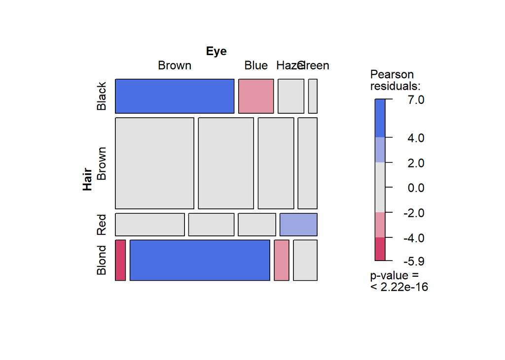

```r
mosaic(~Hair+Eye, data = haireye,shade = TRUE)
```

**모자이크 플롯**을 통해서도 두 변수는 서로 연관성이 있다는 같은 결과를 확인할 수 있다.

```r
HE_S <- loglm(~ Hair * Eye + Sex, data = HairEyeColor)
HE_S
```

```
## Call:
## loglm(formula = ~Hair * Eye + Sex, data = HairEyeColor)
##
## Statistics:
##                       X^2 df  P(> X^2)
## Likelihood Ratio 19.85656 15 0.1775045
## Pearson          19.56712 15 0.1891745
```

위의 Formula는 **Hair**, **Eye**변수가 **Sex**변수에 대해서 공동적으로 독립인지 확인하는 Formula로 **[HairEye][Sex]**모형을 적합시킨다.  
앞에서 진행한 분석과 달리 **Sex**변수에 대해 공동적으로 독립임을 가정하면, 유의확률이 모두 유의하지 않으므로 귀무가설을 기각하지 못하는 것을 확인할 수 있다.  
따라서, **Hair**,**Eye**는 **Sex**변수에 대해서 공동적으로 독립이다. 즉, 연관성이 없다는 것을 확인할 수 있다.

```r
residuals(HE_S, type = "pearson")
```

```
## Re-fitting to get frequencies and fitted values
```

```
## , , Sex = Male
##
##        Eye
## Hair           Brown         Blue        Hazel        Green
##   Black -0.008354888  0.512788125  1.102277378  0.419253811
##   Brown -0.411648401  1.654855326 -0.089068021  0.360508118
##   Red   -0.643733634  0.702407350  0.156512844  0.156512844
##   Blond -0.164611924 -2.148579275  0.132277496  0.167319269
##
## , , Sex = Female
##
##        Eye
## Hair           Brown         Blue        Hazel        Green
##   Black  0.007888066 -0.484136574 -1.040688673 -0.395828400
##   Brown  0.388647936 -1.562391850  0.084091429 -0.340365068
##   Red    0.607765626 -0.663161003 -0.147767837 -0.147767837
##   Blond  0.155414389  2.028529441 -0.124886616 -0.157970463
```

**hair,eye,sex에 대한 3-way 분할표**의 잔차를 살펴보면 위와같은 결과를 얻을 수 있다.  
남성과 여성 모두 **Eye = Blue, Hair = Blond**인 경우의 잔차가 상대적으로 높거나 낮은 것을 확인할 수 있다.  
남성의 경우에는 잔차가 음의 값이므로 관찰빈도가 기대빈도보다 낮고, 여성의 경우에는 잔차가 양의 값이므로 관찰빈도가 기대빈도보다 높은것을 확인할 수 있다.

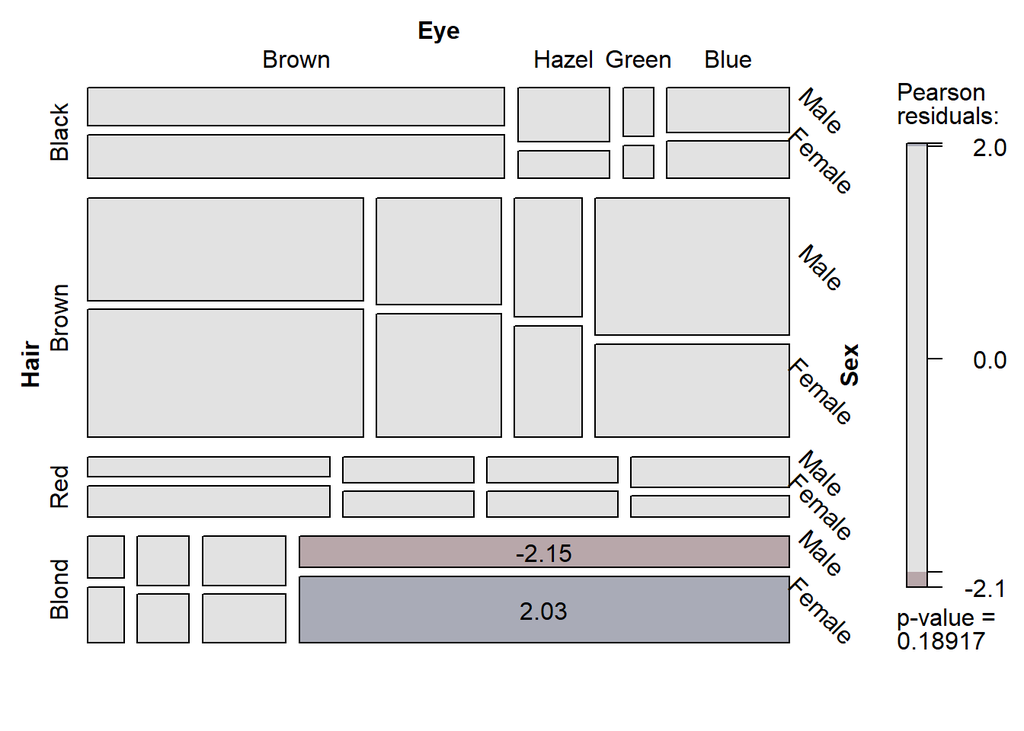

```r
HEC <- HairEyeColor[, c("Brown","Hazel","Green","Blue"),]
mosaic(HEC, expected = ~Hair * Eye + Sex,
       labeling = labeling_residuals,
       digits = 2, rot_labels = c(right = -45))
```

3-way 분할표의 **모자이크 플롯**을 그린 결과는 위와같다.  
잔차를 통해 살펴본 결과와 동일한 셀에 각각 빨간색, 파란색으로 표시된 것을 확인할 수 있으며, 유의확률 또한 유의하지 않은 것을 확인할 수 있다.

### 5.4.2 Fitting models

3개 이상의 변수를 분할표에 나타내는 경우, 변수의 차원이 넓어지게 된다.  
이때, 고려할 변수들이 많아지므로 변수들을 이용하여 모델에 적합시키는 경우, 다양한 독립성 유형의 모델이 나올 수 있고 각 모델의 잔차를 표시할 수 있다.

변수 A,B,C가 있는 3-way 분할표의 경우 적합될 수 있는 가설 모형 중 일부는 아래와 같다.

$H_1$: **Complete independence**: 모델의 formula는 ~A + B + C로 표시되며, 이는 A,B,C가 상호독립이라고 가정한다.

$H_2$: **Joint independence**: 모델의 formula는 ~A*B + C로 표시되며, 변수 C가 공동으로 있는 모형으로 적합시킨다. 변수 C가 변수 A와 B의 조합과 관련이 있지만 해당 연관성이 정확하게 적합되기 때문에 A, B 사이의 연관성을 나타내지는 않는다.

$H_3$: **Conditional independence**: 모델의 formula는 ~ A * C + B * C (or ~ (A + B) * C)으로 표시되며, 이는 C가 제어될 때 A와 B는 조건부 독립이라고 가정한다. 이 모형이 적합하면 모자이크 표시는 C에 대해 제어되는 변수 A와 B사이의 조건부 연관성을 표시하지만 A와C 또는 B와 C사이의 연관성을 표시하지는 않는다.

$H_4$: **No three-way interaction**: 이 모형의 경우 marginally 혹은 conditionally적으로 어떠한 독립적인 쌍이 없다고 가정한다. 그러나 두 변수 간의 연관성은 세 번째 변수의 각 수준에서 동일하다.

*Example 5.8: Hair color, eye color, and sex*

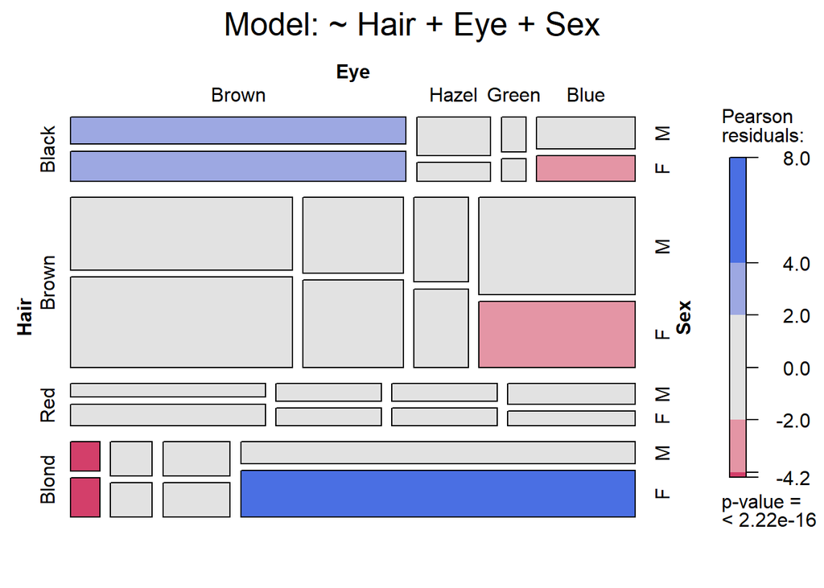

```r
abbrev <- list(abbreviate = c(FALSE,FALSE,1))
mosaic(HEC, expected = ~ Hair + Eye + Sex,
        labeling_args = abbrev,
        main = "Model: ~ Hair + Eye + Sex")
```

위의 그림은 **[Hair][Eye][Sex]**에 대한 상호 독립 모델을 가정하고 적합시킨 모델의 잔차를 표시하는 **모자이크 플롯**이다.  
유의확률은 유의수준 0.05보다 작으므로 귀무가설을 기각한다. 따라서, 위의 세 변수들 중 독립이 아닌 변수들의 쌍이있다고 할 수 있다.

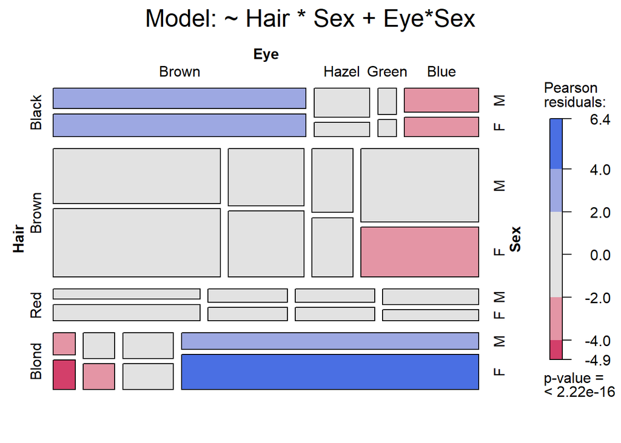

```r
mosaic(HEC, expected = ~ Hair * Sex + Eye * Sex,
       labeling_args = abbrev, main = "Model: ~ Hair * Sex + Eye*Sex")
```

위의 그림은 **{HairSex}[EyeSex]**에 대한 모델로 **Sex**변수가 주어졌을 때, **Hair**,**Eye**변수의 독립성을 가정한 모델이다.  
유의확률이 유의수준 0.05보다 작으므로 귀무가설을 기각한다. 따라서, **Sex**변수가 제어될 때, **Hair**,**Eye**변수는 서로 독립이 아닌것을 알 수 있다.

```r
mod1 <- loglm(~ Hair + Eye + Sex, data = HEC) # [Hair][Eye][Sex]
mod2 <- loglm(~ Hair * Sex + Eye * Sex, data = HEC) # [HairSex][EyeSex]
mod3 <- loglm(~ Hair * Eye + Sex, data = HEC) # [HairEye][Sex]
LRstats(mod1, mod2, mod3)
```

```
## Likelihood summary table:
##         AIC    BIC LR Chisq Df Pr(>Chisq)
## mod1 321.18 332.90  166.300 24     <2e-16 ***
## mod2 323.56 344.08  156.678 18     <2e-16 ***
## mod3 192.74 217.65   19.857 15     0.1775
## ---
## Signif. codes:  0 '***' 0.001 '**' 0.01 '*' 0.05 '.' 0.1 ' ' 1
```

`LRstats`함수를 이용하여 적합시킨 모델들을 서로 비교할 수 있다.  
AIC, BIC, 검정통계량의 경우, **mod3**가 가장 낮은 것을 확인할 수 있었다.  
**mod1, mod2**의 유의확률은 유의수준 0.05보다 작으므로 귀무가설을 기각하여 변수간 독립이 아닌것을 알 수 있고 **mod3**는 유의확률이 유의수준 0.05보다 크므로 귀무가설을 기각하지 못하여 **Sex**변수에 대해서 공동적으로 독립인 것을 알 수 있다.

```r
anova(mod1)
```

```
## Call:
## loglm(formula = ~Hair + Eye + Sex, data = HEC)
##
## Statistics:
##                       X^2 df P(> X^2)
## Likelihood Ratio 166.3001 24        0
## Pearson          164.9247 24        0
```

```r
anova(mod1, mod2, mod3, test = "chisq")
```

```
## LR tests for hierarchical log-linear models
##
## Model 1:
##  ~Hair + Eye + Sex
## Model 2:
##  ~Hair * Sex + Eye * Sex
## Model 3:
##  ~Hair * Eye + Sex
##
##            Deviance df Delta(Dev) Delta(df) P(> Delta(Dev)
## Model 1   166.30014 24
## Model 2   156.67789 18    9.62225         6        0.14149
## Model 3    19.85656 15  136.82133         3        0.00000
## Saturated   0.00000  0   19.85656        15        0.17750
```

## 5.5 Model and plot collections

### 5.5.1 Sequential plots and models

```r
for(nf in 2 : 5){
  print(loglin2string(joint(nf, factors = LETTERS[1:5])))
}
```

```
## [1] "[A] [B]"
## [1] "[A,B] [C]"
## [1] "[A,B,C] [D]"
## [1] "[A,B,C,D] [E]"
```

```r
for (nf in 2 : 5){
  print(loglin2string(conditional(nf, factors = LETTERS[1:5]),sep = ""))
}
```

```
## [1] "[A] [B]"
## [1] "[AC] [BC]"
## [1] "[AD] [BD] [CD]"
## [1] "[AE] [BE] [CE] [DE]"
```

```r
for (nf in 2 : 5){
print(loglin2formula(conditional(nf, factors = LETTERS[1:5])))
}
```

```
## ~A + B
## ~A:C + B:C
## ~A:D + B:D + C:D
## ~A:E + B:E + C:E + D:E
```

```r
loglin2formula(joint(3, table = HEC))
```

```
## ~Hair:Eye + Sex
```

```r
loglin2string(joint(3, table = HEC))
```

```
## [1] "[Hair,Eye] [Sex]"
```

`loglin2string` 혹은 `loglin2formula`함수를 이용하여 모자이크 관련 함수에서 사용할 수 있도록 위의 몇 가지 예제들과 같이 분석하고자 하는 모델 공식 또는 문자열로 변환해준다.

```r
HEC.mods <- seq_loglm(HEC, type = "joint")
LRstats(HEC.mods)
```

```
## Likelihood summary table:
##            AIC    BIC LR Chisq Df Pr(>Chisq)
## model.1 194.40 193.78  165.592  3     <2e-16 ***
## model.2 241.04 246.45  146.444  9     <2e-16 ***
## model.3 192.74 217.65   19.857 15     0.1775
## ---
## Signif. codes:  0 '***' 0.001 '**' 0.01 '*' 0.05 '.' 0.1 ' ' 1
```

그러나, 주어진 유형에 따른 순차적 모델을 직접 입력하는 것은 번거로운 작업일 것이다.  
따라서, 이러한 경우 R에서는 `seq_loglm`함수를 이용하여 간단하게 진행할 수 있다.  
`seq_loglm`함수는 지정한 독립성 유형의 타입에 대해서 가능한 모든 독립성 유형 모델을 순차적으로 적합시켜주는 함수로, `vcdExtra`패키지에 포함돼있다.  
- `seq_loglm(table,type)`

- table: 로그선형모델을 적합시킬 분할표
- type: 분석가가 가정하고자 하는 독립성 유형(“joint”, “conditional”, “mutual”, “markov”, “saturated”)

분석 후, `LRstats`함수를 이용하여 순차적 모델의 결과를 비교할 수도 있다.

`model.1, model.2`의 유의확률은 유의수준 0.05보다 작으므로 귀무가설을 기각하여 변수간 독립이 아닌 것을 확인할 수 있고 `model.3`의 유의확률은 유의수준 0.05보다 크므로 귀무가설을 기각하지 못하여 변수간 독립인 것을 확인할 수 있다.